# Leaderboards for Subchallenge II

Attila Gabor

11/25/2019

# 1 Overview

Here we report some statistics about subchallenge II and evaluate the leaderboard.

Some statistics about challenge II:

- the number of total submissions: 77.
- the number of submissions per rounds
  - round 1: 14
  - round 2: 42
  - round 3: 21
- the number of teams participated in this sub challenge: 25

Nice improvement from roun 1 to round 2 and final round.

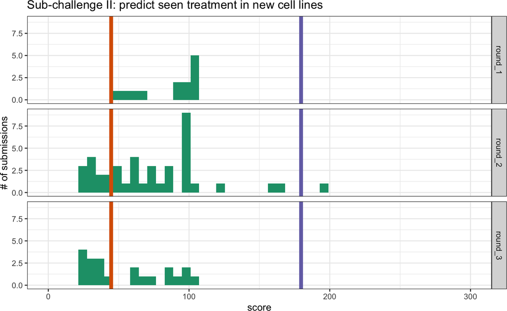

# 2 Leaderboards

Next figure shows all the submissions. We report the scores of each team, ordered by their last submission as we agreed to rank them. The shape of the points indicate in which round they submitted that predictions.

Some teams did not submit in the final rounds in some cases the final submissions were worst than the previous ones.

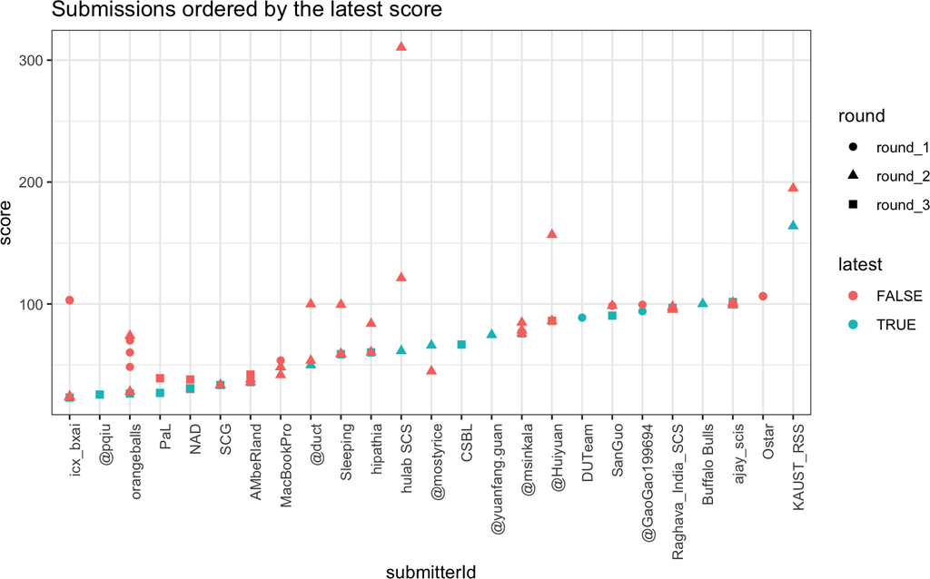

## 2.1 Strict leaderboard

- only teams with submission to round 3
- judging by their latest submission.

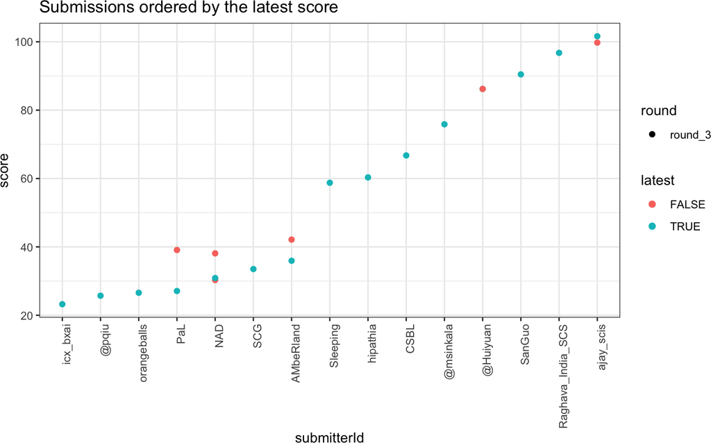

```
## # A tibble: 15 x 3
##    createdOn           submitterId       score
##    <dttm>              <chr>             <dbl>
##  1 2019-11-15 12:43:00 icx_bxai           23.2
##  2 2019-10-31 03:51:00 @pqiu              25.7
##  3 2019-11-15 10:23:00 orangeballs        26.6
##  4 2019-11-11 19:07:00 PaL                27.1
##  5 2019-11-15 12:12:00 NAD                30.9
##  6 2019-11-14 05:03:00 SCG                33.5
##  7 2019-11-12 16:27:00 AMbeRland          35.9
##  8 2019-11-15 02:58:00 Sleeping           58.8
##  9 2019-11-15 06:16:00 hipathia           60.3
## 10 2019-11-16 01:52:00 CSBL               66.8
## 11 2019-11-02 18:40:00 @msinkala          75.9
## 12 2019-11-14 09:35:00 @Huiyuan           86.2
## 13 2019-11-13 04:53:00 SanGuo             90.5
## 14 2019-11-12 07:45:00 Raghava_India_SCS  96.8
## 15 2019-11-13 08:33:00 ajay_scis         102.
```

## 2.2 Leaderboard based on best score

- teams with any submission
- judging by the best score.

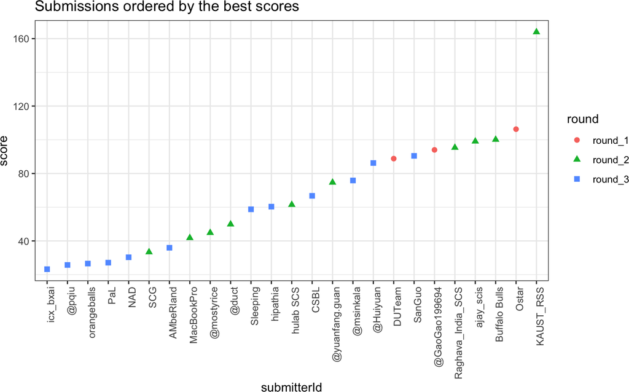

```
## # A tibble: 25 x 4
##    createdOn           submitterId       score round
##    <dttm>              <chr>             <dbl> <chr>
##  1 2019-11-15 12:43:00 icx_bxai           23.2 round_3
##  2 2019-10-31 03:51:00 @pqiu              25.7 round_3
##  3 2019-11-15 10:23:00 orangeballs        26.6 round_3
##  4 2019-11-11 19:07:00 PaL                27.1 round_3
##  5 2019-11-15 08:29:00 NAD                30.3 round_3
##  6 2019-10-29 05:07:00 SCG                33.4 round_2
##  7 2019-11-12 16:27:00 AMbeRland          35.9 round_3
##  8 2019-10-14 01:43:00 MacBookPro         41.8 round_2
##  9 2019-10-23 03:34:00 @mostyrice         44.8 round_2
## 10 2019-10-23 11:03:00 @duct              49.9 round_2
## 11 2019-11-15 02:58:00 Sleeping           58.8 round_3
## 12 2019-11-15 06:16:00 hipathia           60.3 round_3
## 13 2019-10-27 08:29:00 hulab SCS          61.5 round_2
## 14 2019-11-16 01:52:00 CSBL               66.8 round_3
## 15 2019-10-29 04:33:00 @yuanfang.guan     74.7 round_2
## 16 2019-11-02 18:40:00 @msinkala          75.9 round_3
## 17 2019-11-14 09:35:00 @Huiyuan           86.2 round_3
## 18 2019-09-29 03:45:00 DUTeam             88.8 round_1
## 19 2019-11-13 04:53:00 SanGuo             90.5 round_3
## 20 2019-09-28 12:21:00 @GaoGao199694      94.0 round_1
## 21 2019-10-30 06:26:00 Raghava_India_SCS  95.3 round_2
## 22 2019-10-24 07:58:00 ajay_scis          99.1 round_2
## 23 2019-10-24 11:38:00 Buffalo Bulls     100.  round_2
## 24 2019-09-29 10:58:00 Ostar             106.  round_1
## 25 2019-10-30 09:11:00 KAUST_RSS         164.  round_2
```

## 2.3 Leaderboard based on latest submission

- teams with any submission
- judging by the latest score.

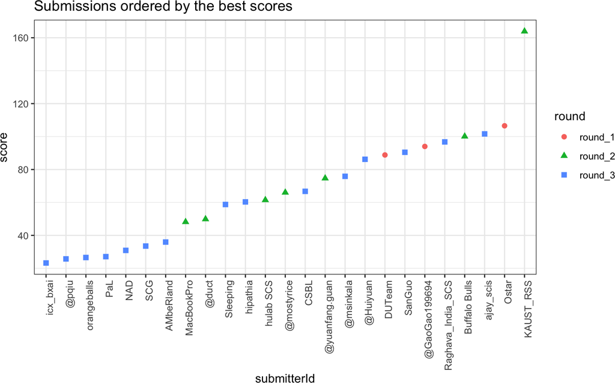

```
## # A tibble: 25 x 5
##    createdOn           submitterId       score round   latest
##    <dttm>              <chr>             <dbl> <chr>   <lgl>
##  1 2019-11-15 12:43:00 icx_bxai           23.2 round_3 TRUE
##  2 2019-10-31 03:51:00 @pqiu              25.7 round_3 TRUE
##  3 2019-11-15 10:23:00 orangeballs        26.6 round_3 TRUE
##  4 2019-11-11 19:07:00 PaL                27.1 round_3 TRUE
##  5 2019-11-15 12:12:00 NAD                30.9 round_3 TRUE
##  6 2019-11-14 05:03:00 SCG                33.5 round_3 TRUE
##  7 2019-11-12 16:27:00 AMbeRland          35.9 round_3 TRUE
##  8 2019-10-25 09:30:00 MacBookPro         48.2 round_2 TRUE
##  9 2019-10-23 11:03:00 @duct              49.9 round_2 TRUE
## 10 2019-11-15 02:58:00 Sleeping           58.8 round_3 TRUE
## 11 2019-11-15 06:16:00 hipathia           60.3 round_3 TRUE
## 12 2019-10-27 08:29:00 hulab SCS          61.5 round_2 TRUE
## 13 2019-10-23 12:08:00 @mostyrice         66.0 round_2 TRUE
## 14 2019-11-16 01:52:00 CSBL               66.8 round_3 TRUE
## 15 2019-10-29 04:33:00 @yuanfang.guan     74.7 round_2 TRUE
## 16 2019-11-02 18:40:00 @msinkala          75.9 round_3 TRUE
## 17 2019-11-14 09:35:00 @Huiyuan           86.2 round_3 TRUE
## 18 2019-09-29 03:45:00 DUTeam             88.8 round_1 TRUE
## 19 2019-11-13 04:53:00 SanGuo             90.5 round_3 TRUE
## 20 2019-09-28 12:21:00 @GaoGao199694      94.0 round_1 TRUE
## 21 2019-11-12 07:45:00 Raghava_India_SCS  96.8 round_3 TRUE
## 22 2019-10-24 11:38:00 Buffalo Bulls     100.  round_2 TRUE
## 23 2019-11-13 08:33:00 ajay_scis         102.  round_3 TRUE
## 24 2019-09-30 01:28:00 Ostar             107.  round_1 TRUE
## 25 2019-10-30 09:11:00 KAUST_RSS         164.  round_2 TRUE
```